# CÁLCULO DA MÉDIA DO IDD

# PROBLEMA

Calcular a média dos cursos da UFTM no IDD.

O IDD é um indicador de qualidade que busca mensurar o valor agregado pelo curso ao desenvolvimento dos estudantes concluintes, considerando seus desempenhos no Enade e no Exame Nacional do Ensino Médio (Enem), como medida proxy (aproximação) das suas características de desenvolvimento ao ingressarem no curso de graduação avaliado. Para que um curso tenha o IDD calculado, é preciso que ele atenda às seguintes condições:

possuir no mínimo dois estudantes concluintes participantes do Enade com dados recuperados da base de dados do Enem no período entre o ano de ingresso no curso avaliado e os três anos anteriores; atingir 20% do total de estudantes concluintes participantes do Enade com dados recuperados da base de dados do Enem. Desde 2014, o cálculo do IDD ocorre para cada indivíduo que tenha participado do Enade e do Enem, recuperando-se os resultados do estudante nos dois exames a partir do número do CPF.

Esse indicador é calculado desde 2007, como componente do CPC. Em 2016, passou a ser divulgado separadamente, vinculado ao mesmo código de curso em que os estudantes concluintes foram inscritos no Enade.

# DATASET

https://www.gov.br/inep/pt-br/acesso-a-informacao/dados-abertos/indicadores-educacionais/indicadores-de-qualidade-da-educacao-superior

CARREGAR MÓDULOS

```r
library(dplyr)
library(stringr)

library(ggplot2)
```

CARREGAR O DATASET

```r
dados <- read.csv2("DADOS/IDD_2019.csv")
```

VERIFICAR O TAMANHO DO DATASET

```r
dim(dados)
```

```
[1] 8368   21
```

VERIFICAR OS COLUNAS DO DATASET

```r
colnames(dados)
```

```
 [1] "Ano"
 [2] "Código.da.Área"
 [3] "Área.de.Avaliação"
 [4] "Código.da.IES"
 [5] "Nome.da.IES"
 [6] "Sigla.da.IES"
 [7] "Organização.Acadêmica"
 [8] "Categoria.Administrativa"
 [9] "Código.do.Curso"
[10] "Modalidade.de.Ensino"
[11] "Código.do.Município"
[12] "Município.do.Curso"
[13] "Sigla.da.UF"
[14] "Nº.de.Concluintes.Inscritos"
[15] "Nº.de.Concluintes.Participantes"
[16] "Nº.de.Concluintes.Participantes.com.nota.no.Enem"
[17] "Proporção.de.Concluintes.participantes.com.nota.no.Enem"
[18] "Nota.Bruta...IDD"
[19] "IDD..Contínuo."
[20] "IDD..Faixa."
[21] "Observação"
```

VERIFICAR OS NOMES DA LINHAS DO DATASET

```r
rownames(dados)[1:30]
```

```
 [1] "1"  "2"  "3"  "4"  "5"  "6"  "7"  "8"  "9"  "10" "11" "12" "13" "14" "15" "16" "17" "18" "19" "20" "21"
[22] "22" "23" "24" "25" "26" "27" "28" "29" "30"
```

VERIFICAR OS TIPOS DOS DADOS DO DATASET

```r
str(dados)
```

```
'data.frame':   8368 obs. of  21 variables:
 $ Ano                                                    : int  2019 2019 2019 2019 2019 2019 2019 2019 2019 2019 ...
 $ Código.da.Área                                         : int  28 6208 5710 5 19 6 17 28 55 36 ...
 $ Área.de.Avaliação                                      : chr  "NUTRIÇÃO" "ENGENHARIA DE PRODUÇÃO" "ENGENHARIA CIVIL" "MEDICINA VETERINÁRIA" ...
 $ Código.da.IES                                          : int  1414 12758 12758 1087 1087 1087 1087 1087 1087 1087 ...
 $ Nome.da.IES                                            : chr  "CENTRO UNIVERSITÁRIO SÃO LUCAS" "FACULDADE DE EDUCAÇÃO E CULTURA DE PORTO VELHO" "FACULDADE DE EDUCAÇÃO E CULTURA DE PORTO VELHO" "FACULDADES INTEGRADAS APARÍCIO CARVALHO" ...
 $ Sigla.da.IES                                           : chr  "UniSL" "FAEC-PVH" "FAEC-PVH" "FIMCA" ...
 $ Organização.Acadêmica                                  : chr  "Centro Universitário" "Faculdade" "Faculdade" "Faculdade" ...
 $ Categoria.Administrativa                               : chr  "Privada com fins lucrativos" "Privada sem fins lucrativos" "Privada sem fins lucrativos" "Privada sem fins lucrativos" ...
 $ Código.do.Curso                                        : int  45877 1193546 1108254 73753 73755 17955 106830 108725 94221 94223 ...
 $ Modalidade.de.Ensino                                   : chr  "Educação Presencial" "Educação Presencial" "Educação Presencial" "Educação Presencial" ...
 $ Código.do.Município                                    : int  1100205 1100205 1100205 1100205 1100205 1100205 1100205 1100205 1100205 1100205 ...
 $ Município.do.Curso                                     : chr  "Porto Velho" "Porto Velho" "Porto Velho" "Porto Velho" ...
 $ Sigla.da.UF                                            : chr  "RO" "RO" "RO" "RO" ...
 $ Nº.de.Concluintes.Inscritos                            : int  30 14 47 53 59 20 55 23 41 32 ...
 $ Nº.de.Concluintes.Participantes                        : int  20 14 42 51 56 19 51 23 34 30 ...
 $ Nº.de.Concluintes.Participantes.com.nota.no.Enem       : int  17 7 35 34 46 11 44 18 28 28 ...
 $ Proporção.de.Concluintes.participantes.com.nota.no.Enem: num  0.85 0.5 0.833 0.667 0.821 ...
 $ Nota.Bruta...IDD                                       : num  1.1832 0.0782 0.5448 0.458 -0.2168 ...
 $ IDD..Contínuo.                                         : num  3.28 2.51 2.97 3.02 2.36 ...
 $ IDD..Faixa.                                            : chr  "4" "3" "4" "4" ...
 $ Observação                                             : chr  "" "" "" "" ...
```

VERIFICAR OS TIPOS DOS DADOS DO DATASET

```r
glimpse(dados)
```

```
Rows: 8,368
Columns: 21
$ Ano                                                     <int> 2019, 2019, 2019, 2019, 2019, 2019, 2019, 2019~
$ Código.da.Área                                          <int> 28, 6208, 5710, 5, 19, 6, 17, 28, 55, 36, 12, ~
$ Área.de.Avaliação                                       <chr> "NUTRIÇÃO", "ENGENHARIA DE PRODUÇÃO", "ENGENHA~
$ Código.da.IES                                           <int> 1414, 12758, 12758, 1087, 1087, 1087, 1087, 10~
$ Nome.da.IES                                             <chr> "CENTRO UNIVERSITÁRIO SÃO LUCAS", "FACULDADE D~
$ Sigla.da.IES                                            <chr> "UniSL", "FAEC-PVH", "FAEC-PVH", "FIMCA", "FIM~
$ Organização.Acadêmica                                   <chr> "Centro Universitário", "Faculdade", "Faculdad~
$ Categoria.Administrativa                                <chr> "Privada com fins lucrativos", "Privada sem fi~
$ Código.do.Curso                                         <int> 45877, 1193546, 1108254, 73753, 73755, 17955, ~
$ Modalidade.de.Ensino                                    <chr> "Educação Presencial", "Educação Presencial", ~
$ Código.do.Município                                     <int> 1100205, 1100205, 1100205, 1100205, 1100205, 1~
$ Município.do.Curso                                      <chr> "Porto Velho", "Porto Velho", "Porto Velho", "~
$ Sigla.da.UF                                             <chr> "RO", "RO", "RO", "RO", "RO", "RO", "RO", "RO"~
$ Nº.de.Concluintes.Inscritos                             <int> 30, 14, 47, 53, 59, 20, 55, 23, 41, 32, 84, 52~
$ Nº.de.Concluintes.Participantes                         <int> 20, 14, 42, 51, 56, 19, 51, 23, 34, 30, 23, 43~
$ Nº.de.Concluintes.Participantes.com.nota.no.Enem        <int> 17, 7, 35, 34, 46, 11, 44, 18, 28, 28, 20, 34,~
$ Proporção.de.Concluintes.participantes.com.nota.no.Enem <dbl> 0.8500000, 0.5000000, 0.8333333, 0.6666667, 0.~
$ Nota.Bruta...IDD                                        <dbl> 1.1832, 0.0782, 0.5448, 0.4580, -0.2168, 0.561~
$ IDD..Contínuo.                                          <dbl> 3.2835, 2.5135, 2.9682, 3.0150, 2.3584, 3.0712~
$ IDD..Faixa.                                             <chr> "4", "3", "4", "4", "3", "4", "3", "3", "3", "~
$ Observação                                              <chr> "", "", "", "", "", "", "", "", "", "", "", ""~
```

VERIFICAR SE O DATASET TEM VALORES MISSING

```r
sapply(dados, function(x) sum(is.na(x)))
```

```
                                                    Ano                                          Código.da.Área
                                                      0                                                       0
                                      Área.de.Avaliação                                           Código.da.IES
                                                      0                                                       0
                                            Nome.da.IES                                            Sigla.da.IES
                                                      0                                                       0
                                  Organização.Acadêmica                                Categoria.Administrativa
                                                      0                                                       0
                                        Código.do.Curso                                    Modalidade.de.Ensino
                                                      0                                                       0
                                    Código.do.Município                                      Município.do.Curso
                                                      0                                                       0
                                            Sigla.da.UF                             Nº.de.Concluintes.Inscritos
                                                      0                                                       0
                        Nº.de.Concluintes.Participantes        Nº.de.Concluintes.Participantes.com.nota.no.Enem
                                                      0                                                       0
Proporção.de.Concluintes.participantes.com.nota.no.Enem                                        Nota.Bruta...IDD
                                                      1                                                     390
                                         IDD..Contínuo.                                             IDD..Faixa.
                                                    390                                                       0
                                             Observação
                                                      0
```

VERIFICAR SE O DATASET TEM VALORES NULOS

```r
sapply(dados, function(x) sum(is.null(x)))
```

```
                                                    Ano                                          Código.da.Área
                                                      0                                                       0
                                      Área.de.Avaliação                                           Código.da.IES
                                                      0                                                       0
                                            Nome.da.IES                                            Sigla.da.IES
                                                      0                                                       0
                                  Organização.Acadêmica                                Categoria.Administrativa
                                                      0                                                       0
                                        Código.do.Curso                                    Modalidade.de.Ensino
                                                      0                                                       0
                                    Código.do.Município                                      Município.do.Curso
                                                      0                                                       0
                                            Sigla.da.UF                             Nº.de.Concluintes.Inscritos
                                                      0                                                       0
                        Nº.de.Concluintes.Participantes        Nº.de.Concluintes.Participantes.com.nota.no.Enem
                                                      0                                                       0
Proporção.de.Concluintes.participantes.com.nota.no.Enem                                        Nota.Bruta...IDD
                                                      0                                                       0
                                         IDD..Contínuo.                                             IDD..Faixa.
                                                      0                                                       0
                                             Observação
                                                      0
```

VERIFICAR OS ID DOS DADOS MISSING

```r
idna <- which(is.na(dados$IDD..Contínuo.))

idna
```

```
  [1]   24  112  135  138  237  241  250  267  269  280  281  294  306  342  422  423  425  450  501  539  643
 [22]  689  788  801  820  832  845  846  887  890  961  981 1092 1093 1098 1224 1238 1319 1453 1497 1498 1642
 [43] 1654 1718 1811 1818 1847 1848 1869 1905 1938 1958 1959 1960 1961 1962 1974 1985 2011 2082 2083 2084 2198
 [64] 2213 2310 2317 2321 2323 2407 2410 2446 2450 2465 2477 2568 2577 2600 2630 2632 2635 2639 2681 2682 2683
 [85] 2685 2688 2699 2756 2948 2950 2971 3196 3201 3228 3261 3277 3295 3304 3306 3350 3443 3465 3466 3475 3492
[106] 3507 3508 3551 3587 3608 3609 3611 3622 3640 3648 3650 3673 3698 3701 3712 3723 3729 3730 3736 3753 3754
[127] 3756 3757 3780 3781 3790 3803 3817 3821 3847 3849 3853 3857 3858 3860 3874 3936 3947 3950 3953 3960 3961
[148] 3962 3963 3964 3986 3993 3999 4000 4022 4043 4078 4146 4149 4151 4176 4177 4180 4189 4191 4192 4194 4199
[169] 4259 4261 4283 4308 4368 4393 4443 4444 4445 4473 4500 4502 4512 4527 4565 4568 4576 4623 4629 4688 4689
[190] 4692 4738 4741 4776 4781 4810 4846 4937 4974 5009 5079 5082 5092 5099 5125 5150 5154 5171 5200 5212 5214
[211] 5227 5229 5248 5257 5269 5270 5278 5289 5290 5291 5294 5304 5351 5356 5359 5367 5371 5373 5423 5424 5428
[232] 5430 5453 5454 5455 5456 5459 5460 5481 5507 5508 5509 5510 5511 5512 5519 5520 5521 5522 5528 5530 5531
[253] 5535 5537 5538 5579 5592 5605 5618 5619 5620 5621 5623 5624 5625 5629 5642 5647 5651 5681 5701 5702 5703
[274] 5724 5725 5793 5804 5822 5823 5831 5848 5856 5898 5915 5917 5934 5939 5953 6050 6063 6101 6132 6142 6148
[295] 6153 6221 6263 6278 6302 6303 6406 6420 6423 6445 6449 6458 6461 6468 6483 6492 6516 6526 6530 6578 6604
[316] 6624 6642 6662 6667 6676 6734 6736 6742 6759 6788 6872 6876 6888 6956 6960 6962 7001 7003 7073 7114 7176
[337] 7189 7190 7192 7233 7235 7241 7249 7299 7315 7332 7344 7381 7397 7398 7423 7437 7439 7443 7448 7459 7463
[358] 7534 7589 7597 7651 7653 7671 7674 7678 7680 7683 7684 7706 7781 7844 7864 7932 7946 7951 7966 7983 8009
[379] 8014 8015 8078 8126 8142 8172 8191 8205 8254 8296 8312 8330
```

VERIFICAR OS DADOS MISSING

```r
dados[idna, 'IDD..Contínuo.']
```

```
  [1] NA NA NA NA NA NA NA NA NA NA NA NA NA NA NA NA NA NA NA NA NA NA NA NA NA NA NA NA NA NA NA NA NA NA NA
 [36] NA NA NA NA NA NA NA NA NA NA NA NA NA NA NA NA NA NA NA NA NA NA NA NA NA NA NA NA NA NA NA NA NA NA NA
 [71] NA NA NA NA NA NA NA NA NA NA NA NA NA NA NA NA NA NA NA NA NA NA NA NA NA NA NA NA NA NA NA NA NA NA NA
[106] NA NA NA NA NA NA NA NA NA NA NA NA NA NA NA NA NA NA NA NA NA NA NA NA NA NA NA NA NA NA NA NA NA NA NA
[141] NA NA NA NA NA NA NA NA NA NA NA NA NA NA NA NA NA NA NA NA NA NA NA NA NA NA NA NA NA NA NA NA NA NA NA
[176] NA NA NA NA NA NA NA NA NA NA NA NA NA NA NA NA NA NA NA NA NA NA NA NA NA NA NA NA NA NA NA NA NA NA NA
[211] NA NA NA NA NA NA NA NA NA NA NA NA NA NA NA NA NA NA NA NA NA NA NA NA NA NA NA NA NA NA NA NA NA NA NA
[246] NA NA NA NA NA NA NA NA NA NA NA NA NA NA NA NA NA NA NA NA NA NA NA NA NA NA NA NA NA NA NA NA NA NA NA
[281] NA NA NA NA NA NA NA NA NA NA NA NA NA NA NA NA NA NA NA NA NA NA NA NA NA NA NA NA NA NA NA NA NA NA NA
[316] NA NA NA NA NA NA NA NA NA NA NA NA NA NA NA NA NA NA NA NA NA NA NA NA NA NA NA NA NA NA NA NA NA NA NA
[351] NA NA NA NA NA NA NA NA NA NA NA NA NA NA NA NA NA NA NA NA NA NA NA NA NA NA NA NA NA NA NA NA NA NA NA
[386] NA NA NA NA NA
```

VEFIRICAR SE A INSTITUIÇÃO TEM DADOS MISSING

```r
dados[dados[idna, 'Código.da.IES' ] == 597, ]
```

| Ano | Código.da.Área | Área.de.Avaliação | Código.da.IES | Nome.da.IES | Sigla.da.IES | Organização.Acadêmica | Categoria.Administrativa | Código.do.Curso | Modalidade.de.Ensino | Código.do.Município | Município.do.Curso | Sigla.da.UF | Nº.de.Concluintes.Inscritos | Nº.de.Concluintes.Participantes | Nº.de.Concluintes.Participantes.com.nota.no.Enem | Proporção.de.Concluintes.participantes.com.nota.no.Enem | Nota.Bruta...IDD | IDD..Contínuo. | IDD..Faixa. | Observação |
| --- | --- | --- | --- | --- | --- | --- | --- | --- | --- | --- | --- | --- | --- | --- | --- | --- | --- | --- | --- | --- |

EXCLUIR OS DADOS MISSING

```r
dados <- dados[-idna, ]
```

VERIFICAR A VARIÁVEL QUE SERÁ CALCULADA

```r
summary(dados$IDD..Contínuo.)
```

```
   Min. 1st Qu.  Median    Mean 3rd Qu.    Max.
  0.000   2.136   2.495   2.507   2.869   5.000
```

PLOTAR A VARIÁVEL CALCULADA

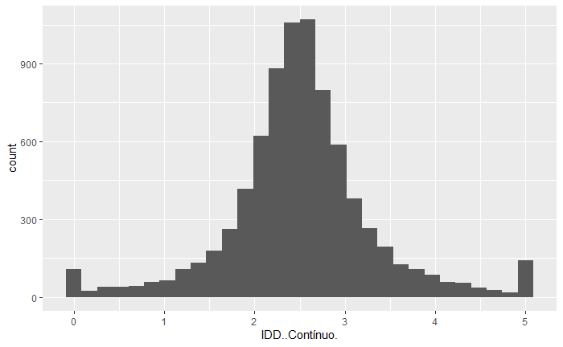

```r
ggplot(dados) +
  aes(IDD..Contínuo.) +
  geom_histogram(bins=30)
```

PLOTAR A VARIÁVEL CALCULADA

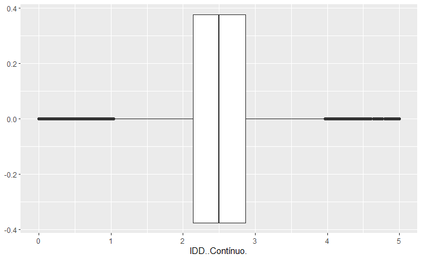

```r
ggplot(dados) +
  aes(IDD..Contínuo.) +
  geom_boxplot()
```

CRIAR UMA VARIÁVEL COM OS CURSOS DA INSTITUICAO

```r
cursos <- dados[dados$Código.da.IES == 597, 'Área.de.Avaliação']

cursos
```

```
 [1] "ENFERMAGEM"                    "BIOMEDICINA"                   "NUTRIÇÃO"
 [4] "FISIOTERAPIA"                  "EDUCAÇÃO FÍSICA (BACHARELADO)" "ENGENHARIA ELÉTRICA"
 [7] "ENGENHARIA MECÂNICA"           "ENGENHARIA CIVIL"              "ENGENHARIA AMBIENTAL"
[10] "ENGENHARIA DE ALIMENTOS"       "ENGENHARIA DE PRODUÇÃO"        "ENGENHARIA QUÍMICA"
[13] "MEDICINA"
```

FUNÇÃO PARA CALCULAR A MÉDIA DO IDD

```r
calculo_media_idd <- function(dados, curso){
  "FUNÇÃO PARA CALCULAR A MÉDIA DO IDD
  ENTRA
    DATASET E O CURSO
  SAI
    A MÉDIA POR CURSO, PÚBLICA, PÚBLICA FEDERAL"

  # FILTRA OS DADOS DA INSTITUIÇÃO
  ddt <- dados %>%
    filter(`Área.de.Avaliação` == curso & `Código.da.IES` == 597)
  # PEGAR A NOTA
  nota <- round(ddt$IDD..Contínuo., 4)
  faixa <- ddt$IDD..Faixa.

  # CALCULAR A MÉDIA PÚBLICA FEDERAL
  ddt <- dados %>%
    filter(`Área.de.Avaliação` == curso & `Categoria.Administrativa` %in% c("Pública Federal",
                                                                            "Pública Estadual",
                                                                            "Pública Municipal" ) )
  media_p <- round(mean(ddt$IDD..Contínuo.), 4)

  # CALCULAR A MÉDIA FEDERAL
  ddt <- dados %>%
    filter(`Área.de.Avaliação` == curso & `Categoria.Administrativa`== "Pública Federal" )
  media_pf <- round(mean(ddt$IDD..Contínuo.), 4)

  return( c(nota, faixa, media_p, media_pf))
}
```

FAZER LOOP NOS CURSOS E CALCULAR A MÉDIA

```r
tb <- c()
for (curso in cursos){
  vl <- calculo_media_idd(dados, curso)
  tb <- rbind(tb, vl)
}

resultado <- as.data.frame(tb)
rownames(resultado) <- cursos
colnames(resultado) <- c(   'IDD_continuo', 'IDD_faixa', 'média_p', 'média_pf')

resultado
```

|  | IDD_continuo | IDD_faixa | média_p | média_pf |
| --- | --- | --- | --- | --- |
| ENFERMAGEM | 2.916 | 3 | 2.7332 | 2.6932 |
| BIOMEDICINA | 2.6461 | 3 | 2.1802 | 2.1426 |
| NUTRIÇÃO | 2.456 | 3 | 2.6546 | 2.7609 |
| FISIOTERAPIA | 3.1163 | 4 | 2.6795 | 2.854 |
| EDUCAÇÃO FÍSICA (BACHARELADO) | 2.7928 | 3 | 2.3549 | 2.4131 |
| ENGENHARIA ELÉTRICA | 2.7434 | 3 | 2.8016 | 2.8603 |
| ENGENHARIA MECÂNICA | 2.0927 | 3 | 2.3818 | 2.4364 |
| ENGENHARIA CIVIL | 2.7902 | 3 | 2.9529 | 3.0002 |
| ENGENHARIA AMBIENTAL | 2.0333 | 3 | 2.5187 | 2.5924 |
| ENGENHARIA DE ALIMENTOS | 2.6322 | 3 | 2.6651 | 2.6665 |

[output cut: 3 more lines]

SALVAR O RESULTADO DO CÁLCULO

```r
write.csv2(resultado, file = 'RESULTADOS/CALCULO - IDD - MÉDIA.csv', na = "", quote = FALSE)
```